# Examen 1 (Métodos Analíticos)

## Parte 2: Aplicación a búsqueda de items populares

Implementaremos una búsqueda de items populares en una muestra de películas de Netflix para mostrar las 15 películas más populares en enero de 2000, junio de 2000 y enero de 2001. Para esto utilizaremos suavizamiento exponencial.

```r
load('./Data/netflix/dat_muestra_nflix.Rdata')
titulos <- read.csv('./Data/netflix/movies_title_fix.csv', header=FALSE)
names(titulos) <- c('peli_id', 'year', 'title')
vistas_ene2000 <- filter(dat.muestra, substr(fecha, 1, 7)=='2000-01')
vistas_jun2000 <- filter(dat.muestra, substr(fecha, 1, 7)=='2000-06')
vistas_ene2001 <- filter(dat.muestra, substr(fecha, 1, 7)=='2001-01')
write.csv(vistas_ene2000$peli_id, file='./Out/vistas_ene2000.csv', row.names = FALSE)
write.csv(vistas_jun2000$peli_id, file='./Out/vistas_jun2000.csv', row.names = FALSE)
write.csv(vistas_ene2001$peli_id, file='./Out/vistas_ene2001.csv', row.names = FALSE)
```

Script en python que hace el suavizamiento exponencial.

```
import csv
lista = {}
c = 1/15
fnames = ['./Out/vistas_ene2000.csv','./Out/vistas_jun2000.csv','./Out/vistas_ene2001.csv']
for fname in fnames:
    with open(fname) as f:
        encabezado = f.readline()
        for line in f:
            item = line.strip('\n')
            for key in lista:
                lista[key] = lista[key]*(1-c)
                if(key==item):
                    lista[key] = lista[key] + c
            if(not (item in lista.keys())):
                lista[item] = c
            lista = {k:v for(k, v) in lista.iteritems() if v >= c/2}
    with open(fname+'_lista_out.csv', 'wb') as f:
        w = csv.writer(f)
        w.writerows(lista.items())
```

```r
system('python suav_exp.py')
```

```r
lista_ene2000 <- read.csv('./Out/vistas_ene2000.csv_lista_out.csv', header=FALSE)
names(lista_ene2000) <- c('peli_id','score')
lista_ene2000_2 <- left_join(lista_ene2000, titulos)
lista_jun2000 <- read.csv('./Out/vistas_jun2000.csv_lista_out.csv', header=FALSE)
names(lista_jun2000) <- c('peli_id','score')
lista_jun2000_2 <- left_join(lista_jun2000, titulos)
lista_ene2001 <- read.csv('./Out/vistas_ene2001.csv_lista_out.csv', header=FALSE)
names(lista_ene2001) <- c('peli_id','score')
lista_ene2001_2 <- left_join(lista_ene2001, titulos)
```

```r
arrange(lista_ene2000_2,score)[1:15,3:4]
```

```
##    year                                      title
## 1  1987 Paul Simon: Graceland: The African Concert
## 2  1948                               Oliver Twist
## 3  1957                                 Men in War
## 4  1990                               Total Recall
## 5  1939                                Love Affair
## 6  1990                                     Misery
## 7  1985                               Return to Oz
## 8  1995                                 True Crime
## 9  1997                              Air Force One
## 10 1996                                    Tin Cup
## 11 1996                           High School High
## 12 1966                      A Man for All Seasons
## 13 1975                  The Man Who Would Be King
## 14 1997                            Broadway Damage
## 15 1979                                   Phantasm
```

En junio de 2000:

```r
arrange(lista_jun2000_2,score)[1:15,3:4]
```

```
##    year                                                    title
## 1  1986                                   Brighton Beach Memoirs
## 2  1999                                       The Big Brass Ring
## 3  1996                                       The Trigger Effect
## 4  1998                                             Storm Riders
## 5  1994 The Battle of the Bulge: World War II's Deadliest Battle
## 6  2000                                                Gladiator
## 7  1997                            Poison Ivy: The New Seduction
## 8  1999                                               Jawbreaker
## 9  1999                                              Happy Texas
## 10 1997                                               The Jackal
## 11 1999                                           Boys Don't Cry
## 12 1996                                Armitage III: Poly-Matrix
## 13 1958                                     Bell Book and Candle
## 14 1991                                                Backdraft
## 15 1981                                    The Fox and the Hound
```

Y en enero de 2001:

```r
arrange(lista_ene2001_2,score)[1:15,3:4]
```

```
##    year                          title
## 1  1997               Albino Alligator
## 2  2000               Heavy Metal 2000
## 3  1944           Arsenic and Old Lace
## 4  1984                      The River
## 5  1963                  Black Sabbath
## 6  1987                     Steel Dawn
## 7  1999         Breakfast of Champions
## 8  1995          Sense and Sensibility
## 9  1989     Born on the Fourth of July
## 10 1999                 Wing Commander
## 11 1989               Drugstore Cowboy
## 12 1979                           1941
## 13 1952                  Wages of Fear
## 14 1945                 Anchors Aweigh
## 15 1964 Treasures of the Twilight Zone
```

## Parte 3: Recomendación

Utilizaremos datos de movielens para construir un sistema de recomendación de películas a usuarios.

Cargamos y analizamos los datos disponibles.

```r
rat <- read.table('./Data/ml-1m/ratings.dat',header=F, sep=":")
rat$V2 <- NULL
rat$V4 <- NULL
rat$V6 <- NULL
names(rat) <- c('user_id','movie_id','rating', 'timestamp')
head(rat)
```

```
##   user_id movie_id rating timestamp
## 1       1     1193      5 978300760
## 2       1      661      3 978302109
## 3       1      914      3 978301968
## 4       1     3408      4 978300275
## 5       1     2355      5 978824291
## 6       1     1197      3 978302268
```

```r
con <- file("./Data/ml-1m/movies.dat", "r", blocking = FALSE)
lineas <- readLines(con) # empty
close(con)
lista.movies <- list()
salida <- lapply(lineas, function(linea){
  sp <- strsplit(linea, '::', fixed=T)[[1]]
  data_frame(movie_id = sp[1], movie_nom = sp[2], tipo = sp[3])
})
movies.df <- rbind_all(salida)
movies.df$movie_id <- as.integer(movies.df$movie_id)
length(unique(rat$user_id))
```

```
## [1] 6040
```

```r
length(unique(rat$movie_id))
```

```
## [1] 3706
```

Tenemos 6040 distintos usuarios y 3706 películas distintas calificadas. Procedemos a crear un conjunto de prueba y uno de entrenamiento.

```r
set.seed(2805)
valida_usuarios <- sample(unique(rat$user_id), length(unique(rat$user_id))*.3 )
valida_pelis <- sample(unique(rat$movie_id), length(unique(rat$movie_id))*.3 )
dat.2 <- rat %>%
  mutate(valida_usu = user_id %in% valida_usuarios) %>%
  mutate(valida_peli = movie_id %in% valida_pelis)
dat.entrena <- filter(dat.2, !valida_usu | !valida_peli)
dat.valida <- filter(dat.2, valida_usu & valida_peli)
dat.entrena[,6] <- NULL
dat.entrena[,5] <- NULL
dat.valida[,6] <- NULL
dat.valida[,5] <- NULL
head(dat.entrena)
```

```
##   user_id movie_id rating timestamp
## 1       1     1193      5 978300760
## 2       1      661      3 978302109
## 3       1      914      3 978301968
## 4       1     3408      4 978300275
## 5       1     2355      5 978824291
## 6       1     1197      3 978302268
```

```r
head(dat.valida)
```

```
##   user_id movie_id rating timestamp
## 1       4     3468      5 978294008
## 2       4     1214      4 978294260
## 3       4     2028      5 978294230
## 4       4     1954      5 978294282
## 5       4     1097      4 978293964
## 6       4     2692      5 978294230
```

```r
#movies.df.v <- movies.df[unique(dat.valida$movie_id),]
#movies.df.e <- movies.df[unique(dat.entrena$movie_id),]
length(unique(dat.entrena$user_id))
```

```
## [1] 6040
```

```r
length(unique(dat.entrena$movie_id))
```

```
## [1] 3696
```

```r
length(unique(dat.valida$user_id))
```

```
## [1] 1812
```

```r
length(unique(dat.valida$movie_id))
```

```
## [1] 1056
```

El conjunto de entrenamiento cuenta con 6040 usuarios y 3696 películas; mientras que el de validación tiene 1812 usuarios y 1056 películas.

Creamos ahora un modelo base de referencia. Este modelo es útil para hacer *benchmarking* de intentos de predicción, como primera pieza para construcción de modelos más complejos, y también como una manera simple de producir estimaciones cuando no hay datos suficientes para hacer otro tipo de predicción. Está definido de la siguiente manera:

Si $x_{ij}$ es el gusto del usuario $i$ por la película $j$, entonces nuestra predicción es $\hat{x}_{ij} = \hat{b}_j + (\hat{a}_i-\hat{\mu} )$ donde $a_i$ indica un nivel general de calificaciones del usuario $i$, y $b_j$ es el nivel general de gusto por la película, definidos como

1. Media general $\hat{\mu} =\frac{1}{T}\sum_{s,t} x_{st}$
2. Promedio de calificaciones de usuario $i$ $\hat{a}_i =\frac{1}{M_i}\sum_{t} x_{i,t}$
3. Promedio de calificaciones de la película $j$ $\hat{b}_j =\frac{1}{N_j}\sum_{s} x_{s,j}$

También podemos escribir la predicción en términos de desviaciones:

$\hat{x}_{ij} = \hat{\mu} + \hat{c}_i + \hat{d}_j$ donde

1. Media general $\hat{\mu} =\frac{1}{T}\sum_{s,t} x_{st}$
2. Desviación de las calificaciones de usuario $i$ respecto a la media general $\hat{c}_i =\frac{1}{M_i}\sum_{t} x_{it} - \hat{\mu}$
3. Desviación de la película $j$ respecto a la media general $\hat{b_j} =\frac{1}{N_j}\sum_{s} x_{sj}- \hat{\mu}.$

Una vez que observamos una calificación $x_{ij}$, el residual del modelo de referencia es $r_{ij} = x_{ij} - \hat{x_{ij}}.$

```r
medias.usuario.e <- dat.entrena %>% group_by(user_id) %>% summarise(media_usu = mean(rating), num_calif_usu = length(rating))
medias.peliculas.e <- dat.entrena %>% group_by(movie_id) %>% summarise(media_peli = mean(rating), num_calif_peli = length(rating))
media.gral.e <- mean(dat.entrena$rating)
dat.entrena.2 <- dat.entrena %>%
  left_join(medias.usuario.e) %>%
  left_join(medias.peliculas.e) %>%
  mutate(media.gral = media.gral.e) %>%
  mutate(rating_adj = media_usu - media.gral + media_peli)
dat.entrena.2$rating_adj[is.na(dat.entrena.2$rating_adj)] <- media.gral.e
dat.entrena.2$res <- dat.entrena.2$rating - dat.entrena.2$rating_adj
dat.entrena.2$u_id <- as.numeric(factor(dat.entrena.2$user_id))
dat.entrena.2$m_id <- as.numeric(factor(dat.entrena.2$movie_id))
medias.peliculas.e$m_id <- arrange(unique(dat.entrena.2[,c(2,13)]), movie_id)[,2]
movies.df <- left_join(movies.df,unique(dat.entrena.2[,c(2,13)]))
movies.df <- movies.df[complete.cases(movies.df),]
length(unique(dat.entrena.2$user_id))
```

```
## [1] 6040
```

```r
length(unique(dat.entrena.2$movie_id))
```

```
## [1] 3696
```

```r
head(dat.entrena.2)
```

```
##   user_id movie_id rating timestamp media_usu num_calif_usu media_peli
## 1       1     1193      5 978300760     4.189            53      4.383
## 2       1      661      3 978302109     4.189            53      3.465
## 3       1      914      3 978301968     4.189            53      4.131
## 4       1     3408      4 978300275     4.189            53      3.864
## 5       1     2355      5 978824291     4.189            53      3.856
## 6       1     1197      3 978302268     4.189            53      4.304
##   num_calif_peli media.gral rating_adj      res u_id m_id
## 1           1223      3.585      4.987  0.01345    1 1104
## 2            525      3.585      4.069 -1.06865    1  640
## 3            459      3.585      4.735 -1.73460    1  853
## 4           1315      3.585      4.468 -0.46776    1 3170
## 5           1208      3.585      4.460  0.54016    1 2159
## 6           2318      3.585      4.908 -1.90759    1 1107
```

```r
dat.valida.2 <- dat.valida %>%
  left_join(unique(dat.entrena.2[,c('user_id', 'u_id', 'm_id')])) %>%
  left_join(medias.usuario.e) %>%
  left_join(medias.peliculas.e) %>%
  mutate(media.gral = media.gral.e) %>%
  mutate(rating_adj = media_usu - media.gral + media_peli)
dat.valida.2$rating_adj[is.na(dat.valida.2$rating_adj)] <- media.gral.e
length(unique(dat.valida.2$user_id))
```

```
## [1] 1812
```

```r
length(unique(dat.valida.2$movie_id))
```

```
## [1] 1056
```

```r
head(dat.valida.2)
```

```
##   user_id movie_id rating timestamp u_id m_id media_usu num_calif_usu
## 1       4     3468      5 978294008    4 1120         4            15
## 2       4     3468      5 978294008    4 2740         4            15
## 3       4     3468      5 978294008    4  971         4            15
## 4       4     3468      5 978294008    4  254         4            15
## 5       4     3468      5 978294008    4  467         4            15
## 6       4     3468      5 978294008    4 1106         4            15
##   media_peli num_calif_peli media.gral rating_adj
## 1         NA             NA      3.585      3.585
## 2         NA             NA      3.585      3.585
## 3         NA             NA      3.585      3.585
## 4         NA             NA      3.585      3.585
## 5         NA             NA      3.585      3.585
## 6         NA             NA      3.585      3.585
```

Ahora evaluamos el error de predicción en el conjunto de validación.

```r
sqrt(mean((dat.valida.2$rating_adj - dat.valida.2$rating)^2))
```

```
## [1] 1.16
```

Una forma de utilizar el modelo base y aumentar si desempeño en la predicción, es usar dimensiones latentes en los datos. Intuitivamente, esto es que en las similitudes entre usuarios, es razonable pensar que hay ciertos “conceptos” que agrupan o separan películas, y que los usuarios se distinguen por el gusto o no que tienen por estos “conceptos”. Esta idea propone que hay ciertos factores latentes (no observados) que describen películas con “contenido implícito similar”, y usuarios según su interés en esa dimensión.

Las dimensiones latentes que se encuentren pueden tener cierta interpretación como “serio-divertido”, o “con violencia-sin violencia”, o puede ser que sean totalmente interpretables, pues se obtienen matemáticamente.

Con $k$ dimensiones latentes, el modelo que proponemos es:

$\tilde{X} = UV^t$

donde $U$ es una matrix de $nxk$ (n= número de usuarios), y $V$ es una matriz de $mxk$, donde $m$ es el número de películas.

Buscamos que, si $X$ son las verdaderas calificaciones, entonces $X\approx \tilde{X}.$

y nótese que esta aproximación es en el sentido de las entradas de $X$ que **son observadas**. Sin embargo, $\tilde{X}$ nos da predicciones para **todos los pares película-persona**.

Bajo este modelo, la predicción para el usuario $i$ y la película $j$ es la siguiente suma sobre las dimensiones latentes:

$\tilde{x}_{ij} =\sum_k u_{ik} v_{jk}$

que expresa el hecho de que el gusto de $i$ por $j$ depende de una combinación (suma) de factores latentes de películas ponderados por gusto por esos factores del usuario.

El número de factores latentes $k$ debe ser seleccionado (por ejemplo, según el error de validación). Dado $k$, para encontrar $U$ y $V$ (un total de $k(m+n)$ parámetros) buscamos minimizar

$\sum_{(i,j)\, obs} (x_{ij}-\tilde{x}_{ij})^2$.

Además de esto, podemos usar también ideas de nuestro modelo base y modelar desviaciones en lugar de calificaciones directamente. Esto es, si $X^0$ son las predicciones del modelo base de referencia, y $R = X-X^0$ son los residuales del modelo base, buscamos mejor $R\approx \tilde{X} = UV^t.$ de manera que las predicciones finales son $X^0 + \tilde{X}.$

Y más aún, podemos usar regularización para que en lugar de optimizar la función de arriba, intentamos más bien minimizar (para una solo factor latente)

$\sum_{(i,j)\, obs} (r_{ij} - u_i v_j)^2 + \lambda \sum_i u_i^2 + \gamma \sum_j v_j^2$.

Si queremos *k* dimensiones latentes, entonces queremos minimizar la función

$\sum_{(i,j)\, obs} (r_{ij} - \sum_{l=1}^{k}{u_{il} v_{jl}})^2 + \lambda \sum_{i,l} u_{il}^2 + \gamma \sum_{j,l} v_{jl}^2$.

Ahora vamos a utilizar descenso en gradiente estocástico para minimizar el error del modelo base y así encontrar los factores latentes en los datos. Primero construimos matrices ralas de usuarios y películas para eficientar el proceso.

```r
i <- dat.entrena.2$u_id
j <- dat.entrena.2$m_id
y <- dat.entrena.2$rating_adj
X <- sparseMatrix(i, j, x = y)
dim(X)

i.v <- dat.valida.2$u_id
j.v <- dat.valida.2$m_id
y.v <- dat.valida.2$rating_adj
X.v <- sparseMatrix(i.v, j.v, x = y.v, dims=dim(X))
dim(X.v)
```

[output not shown]

Compilamos las funciones creadas en C++ para acelerar el proceso. Primero se muestra el código para una función que calcula el error de predicción.

```
#include <Rcpp.h>
using namespace Rcpp;
// [[Rcpp::export]]

double calc_error(NumericVector i, NumericVector j, NumericVector x,
                  NumericMatrix P, NumericMatrix Q, NumericVector a, NumericVector b){
    double suma = 0;
    for(int t = 0; t < i.size(); t++){
        double e = x(t) - a(i[t]-1) - b(j[t]-1)- sum(P(i(t)-1,_)  * Q(j(t)-1,_) );
        suma = suma + e*e;
    }
    double tam = i.size() + 0.0;
    return suma/tam      ;
}
```

Ahora, la función que calcula el gradiente de la función de pérdida cuadrática regularizada.

```
#include <Rcpp.h>
using namespace Rcpp;
// [[Rcpp::export]]

List gradiente(NumericVector i, NumericVector j, NumericVector x,
                  NumericMatrix Pin, NumericMatrix Qin,
                  NumericVector a, NumericVector b,
                  double gamma, double lambda) {
    NumericVector prow;
    NumericVector qrow;
    NumericMatrix Q = clone(Qin);
    NumericMatrix P = clone(Pin);
    NumericVector a1=clone(a);
    NumericVector b1=clone(b);
    double e;

    for(int t = 0; t < i.size(); t++){
         e = x(t) - a1(i(t)-1) - b1(j(t)-1)- sum(P(i(t)-1,_)  * Q(j(t)-1,_) );
         prow = P(i(t)-1,_) + gamma*(e * Q(j(t)-1,_) - lambda* P(i(t)-1,_));
         qrow = Q(j(t)-1,_) + gamma*(e*P(i(t)-1,_) - lambda*Q(j(t)-1,_));
         P(i(t)-1,_) = prow;
         Q(j(t)-1,_) = qrow;
         a1(i(t)-1) = a1(i(t)-1) + gamma*(e-lambda*a1(i(t)-1));
         b1(j(t)-1) = b1(j(t)-1) + gamma*(e-lambda*b(j(t)-1));
    }
    return List::create(P,Q,a1,b1);
}
```

Ahora compliamos las funciones.

```r
Rcpp::sourceCpp('gradiente.cpp')
Rcpp::sourceCpp('calc_error_bias.cpp')
```

La siguiente función recibe como parámetros el número de dimensiones latentes (*k*), la $\gamma$ y la $\lambda$ de regularización y las matrices de entrenamiento y validación de usuario-película en formato ralo para que mediante las funciones mostradas anteriormente minimice el error de predicción usando descenso en gradiente estocástico.

```r
encontrar_dim_latentes <- function(i, j, y, i.v, j.v, y.v, gamma, lambda, k, deltalim){
  X <- sparseMatrix(i, j, x = y)
  X.v <- sparseMatrix(i.v, j.v, x = y.v, dims=dim(X))
  set.seed(2805)
  P <- matrix(rnorm(k*dim(X)[1],0,0.01), ncol=k, nrow=dim(X)[1])
  Q <- matrix(rnorm(k*dim(X)[2],0,0.01), ncol=k, nrow=dim(X)[2])
  a <- rep(0, dim(X)[1])
  b <- rep(0, dim(X)[2])
  l <- 1
  delta <- deltalim+1
  erroresent <- 0
  erroresval <- 0
  while(delta>deltalim & !is.nan(delta) & l<250){
    ee1 <- sqrt(calc_error(i, j, y, P, Q, a, b))
    ev <- sqrt(calc_error(i.v, j.v, y.v, P, Q, a, b))
    erroresent <- append(erroresent,ee1)
    erroresval <- append(erroresval,ev)
    print(l)
    out <- gradiente(i, j, y, P, Q, a, b, gamma, lambda)
    P <- out[[1]]
    Q <- out[[2]]
    a <- out[[3]]
    b <- out[[4]]
    ee2 <- sqrt(calc_error(i, j, y, P, Q, a, b))
    l <- l+1
    delta <- abs(ee2 - ee1)
    print(print(paste('error entrenamiento =',ee2)))
    print(print(paste('error validación =',ev)))
    print(paste('delta =',delta))
  }

  df.it <- data.frame(iter=2:l)
  df.it$erroresent <- round(erroresent[2:l], 3)
  df.it$erroresval <- round(erroresval[2:l], 3)
  l<-list(Q,P,df.it)
  names(l) <- c('Q', 'P', 'err')
  l
}
```

Debido a que se tienen que estimar distintos parámetros libres (*k*, $\gamma$ y $\lambda$), probamos distintas combinaciones para ver cuál tiene el menor error de validación.

```r
dimensiones_lat<- lapply(c(5, 20, 50), function(l) lapply(c(0.002,0.02,0.2), function(m) lapply(c(0.001,0.01,0.1), function(n) {
  print(paste('dim=',l))
  print(paste('gamma=',m))
  print(paste('lambda=',n))
  temp <- encontrar_dim_latentes(i,j,y,i.v,j.v,y.v,m,n,l,0.001)
  save(temp, file=paste0(paste('./Data/dimlat',l,m,n),'.Rdata') )
  rm(temp)} )))
```

Se prueban las matrices $P$ y $Q$ estimadas en el conjunto de validación y se grafican los errores de entrenamiento y validación.

```r
files <- c('./Data/dimlat 20 0.002 0.001.Rdata', './Data/dimlat 20 0.002 0.01.Rdata', './Data/dimlat 20 0.002 0.1.Rdata', './Data/dimlat 20 0.02 0.001.Rdata', './Data/dimlat 20 0.02 0.01.Rdata', './Data/dimlat 20 0.02 0.1.Rdata', './Data/dimlat 20 0.2 0.001.Rdata', './Data/dimlat 20 0.2 0.01.Rdata', './Data/dimlat 20 0.2 0.1.Rdata', './Data/dimlat 50 0.002 0.001.Rdata', './Data/dimlat 50 0.002 0.01.Rdata', './Data/dimlat 50 0.002 0.1.Rdata', './Data/dimlat 5 0.001 0.001.Rdata', './Data/dimlat 5 0.001 0.01.Rdata', './Data/dimlat 5 0.001 0.1.Rdata', './Data/dimlat 5 0.002 0.001.Rdata', './Data/dimlat 50 0.02 0.001.Rdata', './Data/dimlat 5 0.002 0.01.Rdata', './Data/dimlat 50 0.02 0.01.Rdata', './Data/dimlat 5 0.002 0.1.Rdata', './Data/dimlat 50 0.02 0.1.Rdata', './Data/dimlat 5 0.01 0.001.Rdata', './Data/dimlat 5 0.01 0.01.Rdata', './Data/dimlat 5 0.01 0.1.Rdata', './Data/dimlat 5 0.02 0.001.Rdata', './Data/dimlat 50 0.2 0.001.Rdata', './Data/dimlat 5 0.02 0.01.Rdata', './Data/dimlat 50 0.2 0.01.Rdata', './Data/dimlat 5 0.02 0.1.Rdata', './Data/dimlat 50 0.2 0.1.Rdata', './Data/dimlat 5 0.1 0.001.Rdata', './Data/dimlat 5 0.1 0.01.Rdata', './Data/dimlat 5 0.2 0.001.Rdata', './Data/dimlat 5 0.2 0.01.Rdata', './Data/dimlat 5 0.2 0.1.Rdata')

errores <- data.frame()
p <- list()
for(i in 1:length(files)){
  f <- files[i]
  load(f)
  e <- tail(temp$err,1)
  boolean <- sum(is.nan(temp$Q))>0 | sum(is.nan(temp$P))>0
  if(boolean) {e[2] <- NaN; e[3] <- NaN}
  t <- gsub('?.Rdata', '\\1',gsub('^[^_]*dimlat ', '\\1', f))
  errores <- rbind(errores, cbind(e,file=t))
  df <- gather(temp$err, iter)
  names(df) <- c('iter', 'tipo', 'val')
  if(!boolean) p[[i]] <- ggplot(data=df, aes(x=iter, y=val, colour=tipo)) + geom_point() + geom_path() + ggtitle(t)
}
errores$id <- as.numeric(factor(errores$file))
errores
```

```
##     iter erroresent erroresval           file id
## 58    59      0.061      0.747 20 0.002 0.001  1
## 581   59      0.064      0.743  20 0.002 0.01  2
## 45    46      0.202      0.731   20 0.002 0.1  3
## 20    21      0.022      0.743  20 0.02 0.001  4
## 16    17      0.036      0.738   20 0.02 0.01  5
## 18    19      0.114      0.726    20 0.02 0.1  6
## 11    12      0.020      0.738   20 0.2 0.001  7
## 17    18        NaN        NaN    20 0.2 0.01  8
## 2      3        NaN        NaN     20 0.2 0.1  9
## 582   59      0.061      0.746 50 0.002 0.001 10
## 583   59      0.064      0.743  50 0.002 0.01 11
## 46    47      0.201      0.731   50 0.002 0.1 12
## 116  117      0.062      0.747  5 0.001 0.001 13
## 115  116      0.064      0.743   5 0.001 0.01 14
```

[output cut: 21 more lines]

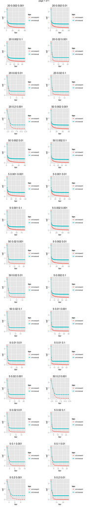

```r
do.call(marrangeGrob, c(p[!sapply(p, is.null)], ncol=2, heights=10))
```

Podemos notar que hubo ciertos casos de *overflow* numérico, sin embargo, consideramos que fueron pocos y por el momento se desechan estos casos y se trabaja con los que no tuvieron errores numéricos. A continuación se grafican los errores de entrenamiento y validación de cada caso.

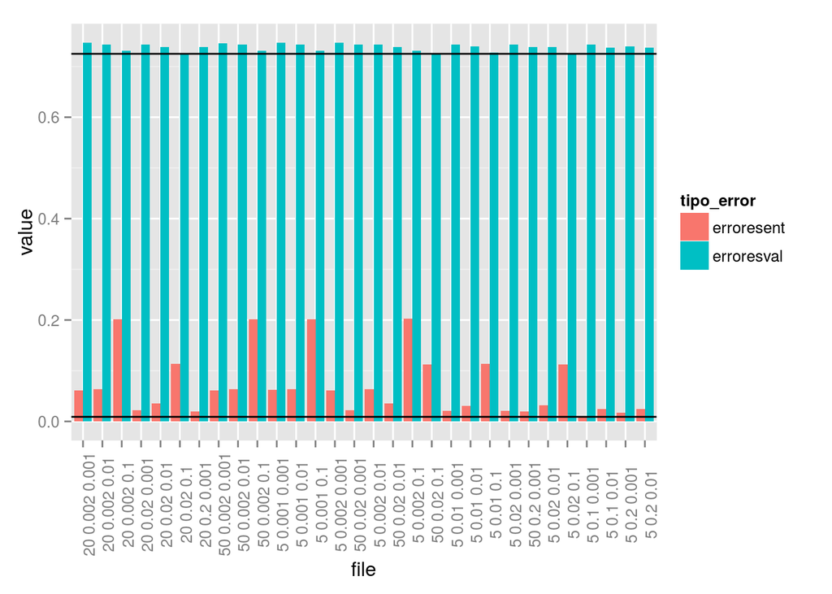

```r
errores_df <- gather(errores[complete.cases(errores),2:4], file)
names(errores_df) <- c('file','tipo_error', 'value')
ggplot(errores_df) + geom_bar(aes(x=file, y=value, fill=tipo_error), position="dodge", stat="identity") +
    theme(axis.text.x = element_text(angle=90, vjust=1)) +
    geom_hline(yintercept=min(errores$erroresval, na.rm=TRUE)) +
    geom_hline(yintercept=min(errores$erroresent, na.rm=TRUE))
```

Analicemos algunos usuarios. En particular el usuario usuario 4000 y el usuario 6000, y usuario 1333. Se les recomendarán películas que no hayan visto basado en el modelo de factores latentes.

```r
load('./Data/dimlat 5 0.1 0.001.Rdata')

xx <- data.frame(movies.df %>% arrange(movie_id), temp$Q)

usuario1 <- 4000
usuario2 <- 6000
usuario3 <- 1333

usuarios <- c(4000,6000,1333)

pred_l <- list(); i=1; califs.2 <- list();
for(usuario in usuarios){
  a<-filter(dat.entrena.2,u_id==usuario)$m_id
  califs.1 <- dat.entrena.2 %>% filter(u_id==usuario) %>%
    arrange(desc(rating_adj))
  califs.2[[i]] <- left_join(califs.1, movies.df)
  pred_l[[i]] <- data.frame(medias.peliculas.e, pred.x =  temp$Q%*%temp$P[usuario, ] ) %>%
    inner_join(movies.df[!(movies.df$m_id %in% a),]) %>%
    arrange(desc(pred.x))
  i=i+1
}
```

Para el usuario 4000, la primera tabla contiene las películas que calificó por encima del promedio, es decir, las que más le gustaron, y en la segunda tabla están las recomendaciones que se le dan.

```r
head(califs.2[[1]],30)[,14:15]
```

```
##                                 movie_nom
## 1              Maltese Falcon, The (1941)
## 2          Godfather: Part II, The (1974)
## 3                        Chinatown (1974)
## 4        Manchurian Candidate, The (1962)
## 5                      Matrix, The (1999)
## 6               Young Frankenstein (1974)
## 7                           Psycho (1960)
## 8                L.A. Confidential (1997)
## 9                            Alien (1979)
## 10                    Shining, The (1980)
## 11                            Jaws (1975)
## 12      Terminator 2: Judgment Day (1991)
## 13              Back to the Future (1985)
## 14                   Exorcist, The (1973)
```

[output cut: 47 more lines]

```r
head(pred_l[[1]],20)[,c(6,7)]
```

```
##                                  movie_nom           tipo
## 1                          Lamerica (1994)          Drama
## 2                 Bittersweet Motel (2000)    Documentary
## 3                    Jupiter's Wife (1994)    Documentary
## 4                  Apple, The (Sib) (1998)          Drama
## 5                 Return with Honor (1998)    Documentary
## 6        Beans of Egypt, Maine, The (1994)          Drama
## 7                             Dingo (1992)          Drama
## 8                 Arguing the World (1996)    Documentary
## 9              Contempt (Le Mépris) (1963)          Drama
## 10                  Song of Freedom (1936)          Drama
## 11                    On Any Sunday (1971)    Documentary
## 12                     Losing Chase (1996)          Drama
## 13                           Target (1995)   Action|Drama
## 14 I Can't Sleep (J'ai pas sommeil) (1994) Drama|Thriller
## 15                       Mamma Roma (1962)          Drama
## 16                    Specials, The (2000)         Comedy
## 17                   Dangerous Game (1993)          Drama
## 18                            Lured (1947)          Crime
## 19                            Faces (1968)          Drama
## 20                       Dancemaker (1998)    Documentary
```

Para el usuario 6000, las tablas son de la misma forma que para el usuario anterior.

```r
head(califs.2[[2]],30)[,14:15]
```

```
##                                                movie_nom
## 1                       Shawshank Redemption, The (1994)
## 2                                  Godfather, The (1972)
## 3                                Schindler's List (1993)
## 4                             Usual Suspects, The (1995)
## 5                         Raiders of the Lost Ark (1981)
## 6              Star Wars: Episode IV - A New Hope (1977)
## 7                                Sixth Sense, The (1999)
## 8                             Maltese Falcon, The (1941)
## 9                               Great Escape, The (1963)
## 10                                   Citizen Kane (1941)
## 11                                      Chinatown (1974)
## 12                Monty Python and the Holy Grail (1974)
## 13                      Manchurian Candidate, The (1962)
## 14                                    Matrix, The (1999)
```

[output cut: 47 more lines]

```r
head(pred_l[[2]],20)[,c(6,7)]
```

```
##                               movie_nom                      tipo
## 1              One Little Indian (1973)      Comedy|Drama|Western
## 2              Bittersweet Motel (2000)               Documentary
## 3         Sugarland Express, The (1974)                     Drama
## 4                For All Mankind (1989)               Documentary
## 5                           Cosi (1996)                    Comedy
## 6   Faster Pussycat! Kill! Kill! (1965)       Action|Comedy|Drama
## 7                          Wings (1927)         Drama|Romance|War
## 8                 That Darn Cat! (1965) Children's|Comedy|Mystery
## 9             Blackbeard's Ghost (1968)         Children's|Comedy
## 10 Billy's Hollywood Screen Kiss (1997)            Comedy|Romance
## 11                      Lamerica (1994)                     Drama
## 12                         Lured (1947)                     Crime
## 13         When Night Is Falling (1995)             Drama|Romance
## 14           Bedroom Window, The (1987)                  Thriller
## 15                  Going My Way (1944)                    Comedy
## 16                  Tingler, The (1959)                    Horror
## 17                  Trees Lounge (1996)                     Drama
## 18           Trouble in Paradise (1932)            Comedy|Romance
## 19                   Circus, The (1928)                    Comedy
## 20                     Limelight (1952)                     Drama
```

Para el usuario 1333.

```r
head(califs.2[[3]],30)[,14:15]
```

```
##                                                                      movie_nom
## 1                                                                 Dingo (1992)
## 2          Seven Samurai (The Magnificent Seven) (Shichinin no samurai) (1954)
## 3                                             Shawshank Redemption, The (1994)
## 4                                                        Godfather, The (1972)
## 5                                                      Schindler's List (1993)
## 6                                                   Usual Suspects, The (1995)
## 7                                               Raiders of the Lost Ark (1981)
## 8                                                           Rear Window (1954)
## 9  Dr. Strangelove or: How I Learned to Stop Worrying and Love the Bomb (1963)
## 10                                   Star Wars: Episode IV - A New Hope (1977)
## 11                                                       Third Man, The (1949)
## 12                                                     Double Indemnity (1944)
## 13                                                     Sixth Sense, The (1999)
## 14                                                   Lawrence of Arabia (1962)
```

[output cut: 47 more lines]

```r
head(pred_l[[3]],20)[,c(6,7)]
```

```
##                                     movie_nom           tipo
## 1                           Bells, The (1926)    Crime|Drama
## 2                      Song of Freedom (1936)          Drama
## 3     I Can't Sleep (J'ai pas sommeil) (1994) Drama|Thriller
## 4                       Big Combo, The (1955)      Film-Noir
## 5                         Losing Chase (1996)          Drama
## 6                       Jupiter's Wife (1994)    Documentary
## 7                 Another Man's Poison (1952)    Crime|Drama
## 8           Beans of Egypt, Maine, The (1994)          Drama
## 9         Callejón de los milagros, El (1995)          Drama
## 10                   Return with Honor (1998)    Documentary
## 11                   Arguing the World (1996)    Documentary
## 12 Inheritors, The (Die Siebtelbauern) (1998)          Drama
## 13                          Dancemaker (1998)    Documentary
## 14                    Apple, The (Sib) (1998)          Drama
## 15              End of the Affair, The (1955)          Drama
## 16                          Mamma Roma (1962)          Drama
## 17                        New Age, The (1994)          Drama
## 18                       Feast of July (1995)          Drama
## 19           Friend of the Deceased, A (1997)   Comedy|Drama
## 20                            Lamerica (1994)          Drama
```